# RELIABILITY: TIME VARIANCE

In this example, UQ[py]Lab is used to compute the outcrossing rate $\nu^+$ in a non-stationary time-variant reliability problem using the so-called PHI2 method.

For details, see: Sudret, B. (2008). Analytical derivation of the outcrossing rate in time-variant reliability problems. Structure and Infrastructure Engineering, 4 (5), 353-362 (Section 5). <https://doi.org/10.1080/15732470701270058 DOI:10.1080/15732470701270058>

## THEORY

### Problem statement

The limit state function is defined as the difference between a degrading resistance $r(t) = R - b\, t$ and a time-varying load $S(t)$:

$$g(t, R, S) = R-bt-S(t)$$

where:

- $R$: the resistance, modeled by a Gaussian random variable of mean value $\mu_R$ and standard deviation $\sigma_R$
- $b$: (deterministic) deterioration rate of the resistance
- $t$: time
- $S(t)$: time-varying stress, which is modeled by a stationary Gaussian process of mean value $\mu_S$, standard deviation $\sigma_S$ and square-exponential autocorrelation function $\rho_S(t) = \exp(- (t/\ell)^2)$

### PHI2 Method

The outcrossing rate from the safe to the failure domain is then defined by:

$$\nu^+(t) =\lim_{\Delta t \rightarrow 0} \frac{P[(g(t)>0)\cap (g(t+\Delta t)\leq 0)]}{\Delta t}$$

The limit state functions at two different times can be written as $g(t) = R-bt-S_1$ and $g(t+\Delta t) = R-b(t+\Delta t)-S_2$, where the two stress variables $S_1$ and $S_2$ are correlated:

$$\rho_{S_1,S_2} = \exp(- (\Delta t/\ell)^2)$$

THE PHI2 method solves two FORM analysis at time instant $t$ and $t+\Delta t$, then estimates the outcrossing rate from the parallel system probability of failure defined above:

$$\nu^+_{PHI2}(t) = \frac{\Phi_2(\beta(t), -\beta(t+ \Delta t ), -\alpha(t) \cdot \alpha(t+\Delta t))}{\Delta t}$$

where:

- $\beta(t)$ (resp. $\beta(t+ \Delta t)$): the time-invariant Hasofer-Lind reliability index at time instant t (resp. $t+ \Delta t$)
- $\alpha(t)$: unit vector to the design point in the standard normal space.

### Analytical reference solution

According to Sudret (2008), for the example under consideration, an analytical expression of the outcrossing rate can be derived:

$$\nu^+(t) = \omega_0 \Psi\left( \frac{-b}{\omega_0 \sigma_S} \right) \frac{\sigma_S}{\sqrt{\sigma_R^2+\sigma_S^2}}\ \varphi\left( \frac{\mu_R-bt-\mu_S}{\sqrt{\sigma_R^2+\sigma_S^2}} \right)$$

In this example, pairs of FORM analyses are carried out at different time instants so as to compute the outcrossing rate as a function of time. The PHI2 solution is compared to the analytical solution. Note that another Eq.(41) of Sudret (2008) is implemented in this example. The more stable Eq. (40) of the same reference could be also used.

## INITIALIZE UQ[PY]LAB

### Package imports

```python
from uqpylab import sessions, display_util
import numpy as np
from scipy.stats import norm
from scipy.stats import multivariate_normal as mvn
import matplotlib.pyplot as plt
%matplotlib notebook
```

### Initialize common plotting parameters

```python
display_util.load_plt_defaults()
uq_colors = display_util.get_uq_color_order()
```

### Start a remote UQCloud session

```python
# Start the session
mySession = sessions.cloud()
# (Optional) Get a convenient handle to the command line interface
uq = mySession.cli
# Reset the session
mySession.reset()
```

```
Processing .
```

```
.
```

```
 done!

 uqpylab.sessions :: INFO     :: This is UQ[py]Lab, version 1.00, running on https://uqcloud.ethz.ch.
                                 UQ[py]Lab is free software, published under the open source BSD 3-clause license.
                                 To request special permissions, please contact:
                                  - Stefano Marelli (marelli@ibk.baug.ethz.ch).
                                 A new session (d53505beb71746f482573929deb96770) started.
```

```
 uqpylab.sessions :: INFO     :: Reset successful.
```

### Set the random seed for reproducibility

```python
uq.rng(1,'twister');
```

## APPLICATION

Assume the following:

- Resistance: $\mu_R=5$, $\sigma_R = 0.3$
- Stress: $\mu_S = 3$, $\sigma_S = 0.5$
- Deterioration rate $b=0.01$
- Time $t$ = [0:1:50], $\Delta t =10^{-3}$
- Squared exponential correlation model with correlation length of $\ell=10$

```python
muR, sigmaR = 5, 0.3
muS, sigmaS = 3, 0.5
b = 0.01
t = 0
deltat = 0.001
l = 10
```

The assumptions above lead to a correlation between $S_1$ and $S_2$ of

```python
rho_12 = np.exp(-deltat**2/l**2)
```

and a cycle rate of

```python
omega_0 = np.sqrt(2/l**2)
```

Then, the analytical outcrossing rate is (Sudret, 2008, Eq.(46)):

```python
PSI = lambda x: norm.pdf(x) - x* norm.cdf(-x)
v = omega_0 * PSI(-b/(omega_0*sigmaS)) * \
    (sigmaS/np.sqrt(sigmaR**2+sigmaS**2)) * \
    norm.pdf((muR-b*t-muS)/np.sqrt(sigmaR**2+sigmaS**2))
```

## PROBABILISTIC INPUT MODEL

In order to account for the correlation of $S_1$ and $S_2$, define a three-dimensional input vector as follows:

```python
InputOpts = {
    "Marginals": [
        {"Name": "R",               # Resistance
         "Type": "Gaussian",
         "Moments": [muR, sigmaR]
        },
        {"Name": "S_1",               # Gaussian process at t
         "Type": "Gaussian",
         "Moments": [muS, sigmaS]
        },
        {"Name": "S_2",               # Gaussian process at t+Delta_t
         "Type": "Gaussian",
         "Moments": [muS, sigmaS]
        },
    ]
}
```

The computed correlation coefficient is used:

```python
InputOpts["Copula"] = {
    "Type": 'Gaussian',
    "Parameters": [[1, 0, 0], [0, 1, rho_12], [0, rho_12, 1]]
}
```

Create an INPUT object based on the defined marginals and copula:

```python
myInput = uq.createInput(InputOpts)
```

## LIMIT STATE FUNCTION

The limit state function returns a two-dimensional output related to:

$$g_1(\mathbf{x}) = R-b\, t - S_1 ,\quad g_2(\mathbf{x}) = R-b\, (t+\Delta t) - S_2$$

where $\mathbf{x} = \{R, S_1, S_2\}$ is the vector of input variables.

Define the limit state function using a string in a vectorized expression. The values of time instants are passed as parameters P(1) and P(2):

```python
LSOpts = {
    'Type': 'Model',
    'mString': '[(X(:,1)-'+str(b)+'*P(1)-X(:,2)) X(:,1)-'+ str(b)+'*P(2)-X(:,3) ]',
    'Parameters': [t, t+deltat]
}
```

Create a MODEL object of the limit state function:

```python
myLimitState = uq.createModel(LSOpts)
```

## RELIABILITY ANALYSIS

A FORM analysis is conducted to estimate the two failure probabilities at time instants $t$ and $t+\Delta t$. Note that FORM can carry out several analysis related to each output limit state function in a single call.

Select FORM as the reliability analysis method:

```python
FORMOpts = {
    "Type": "Reliability",
    "Method":"FORM"
}
```

Run the FORM analysis:

```python
myFORM = uq.createAnalysis(FORMOpts)
```

## ESTIMATION OF THE OUTCROSSING RATE

Using the same equations as in |Reliability-4-ParallelSystem|, the parallel system failure probability can be estimated as follows:

```python
betaS1 = myFORM['Results']['BetaHL'][0]
betaS2 = myFORM['Results']['BetaHL'][1]

alpha1 = (-np.array(myFORM['Results']['Ustar'])[:,0] / betaS1).flatten()
alpha2 =  (np.array(myFORM['Results']['Ustar'])[:,1] / betaS2).flatten()

mu = np.zeros(2)
B = np.array([-betaS1, betaS2])
R = np.array([[ 1, alpha1@alpha2],
              [alpha1@alpha2, 1]])
dist = mvn(mean=mu, cov=R)
Pf_FORM = dist.cdf(-B)
```

And finally, compute the outcrossing rate:

```python
v_FORM = Pf_FORM / deltat
```

## COMPARISON TO THEORETICAL RESULTS

```python
print('Outcrossing rate (t=0)')
print('-------------------------------------')
print('Theoretical       : {:11.4e}'.format(v))
print('FORM approximation: {:11.4e}'.format(v_FORM))
```

```
Outcrossing rate (t=0)
-------------------------------------
Theoretical       :  6.3889e-05
FORM approximation:  6.3891e-05
```

## EVOLUTION IN TIME OF THE OUTCROSSING RATE

Set time varying between $t = 0$ and $t = 50$ and compute the analytical outcrossing rate for each time instant:

```python
tt = np.arange(0, 51, 1)
vv = omega_0 * PSI(-b/(omega_0*sigmaS)) * \
    (sigmaS/np.sqrt(sigmaR**2+sigmaS**2)) * \
    norm.pdf((muR-b*tt-muS)/np.sqrt(sigmaR**2+sigmaS**2))
```

Use the same limit state function and FORM options as before

```python
LSiOpts = LSOpts.copy()
FORMiOpts = FORMOpts.copy()
FORMiOpts['Display'] = 0
```

Compute the approximated outcrossing rate by the PHI2 method at each time instant:

```python
vv_FORM = np.zeros((len(tt),1))  # Initialize variable
for ii in range(len(tt)):
    LSiOpts['Parameters'] = [tt[ii].item(), tt[ii].item()+deltat]
    myLimitStatei = uq.createModel(LSiOpts)
    myFORMi = uq.createAnalysis(FORMiOpts)
    betaS1i = myFORMi['Results']['BetaHL'][0]
    betaS2i = myFORMi['Results']['BetaHL'][1]
    alpha1i = (-np.array(myFORMi['Results']['Ustar'])[:,0] / betaS1i).flatten()
    alpha2i = (np.array(myFORMi['Results']['Ustar'])[:,1] / betaS2i).flatten()
    mui = np.zeros(2)
    Bi = np.array([-betaS1i, betaS2i])
    Ri = np.array([[1, alpha1i@alpha2i],
                   [alpha1i@alpha2i,1]])
    disti = mvn(mean=mui, cov=Ri)
    Pf_FORMi = disti.cdf(-Bi)
    vv_FORM[ii] = Pf_FORMi / deltat
```

Plot the outcrossing rate as a function of time (analytical versus PHI2 values):

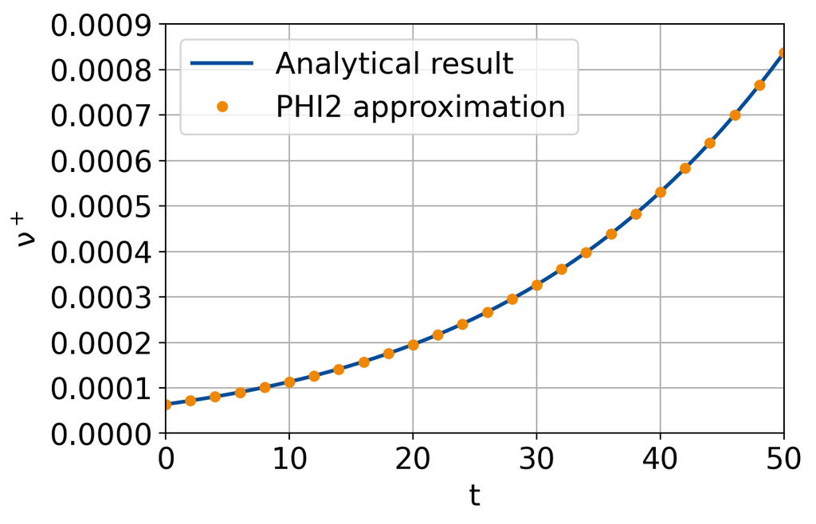

```python
fontsize=16
plt.plot(tt, vv, '-', linewidth=2, color=uq_colors[0], label='Analytical result')
plt.plot(tt[::2], vv_FORM[::2], 'o', markeredgecolor=uq_colors[1],
         markerfacecolor=uq_colors[1], markersize=5, label='PHI2 approximation')
plt.xlim([0, 50])
plt.ylim([0, 9e-4])
plt.xticks(np.arange(0,51,10))
plt.yticks(np.arange(0,1e-3,1e-4))
plt.legend(fontsize=fontsize)
plt.xlabel('t',fontsize=fontsize)
plt.ylabel('$\\mathrm{\\nu^+}$',fontsize=fontsize)
plt.tick_params(axis='both', labelsize=fontsize)
```

## TERMINATE THE REMOTE UQCLOUD SESSION

```python
mySession.quit()
```

```
 uqpylab.sessions :: INFO     :: Session d53505beb71746f482573929deb96770 terminated.
```

```
True
```